# Homework 5

Author

Nicole Friedl

Published

February 26, 2025

## Part 1: Study 1: Predicting per-capita public expenditure based on metropolitan population levels

A sociologist wants to know whether the percentage of a state’s population living in a metropolitan area can predict per-capita state and local public expenditure. Put simply, do cities cost the state more money? She acquired data from forty-eight states (excluding Hawaii and Alaska because she does not have enough funding to travel out of the continental U.S.). Data include how much public money (in dollars) is spent on each individual on average for the year of 1960 (`Ex`), the percentage of population living in metropolitan areas in each state (`MET`), and a dichotomous variable denoting whether or not it is relatively costly to maintain public infrastructure (`grp`).

**Codebook:**

- `ex`: Per capita state and local public expenditures ($). Values: 40.14 - 1346.96
- `met`: Metro population, i.e., percentage of population living in standard metropolitan areas. Values: 0-86.5
- `grp`: Low infrastructure maintenance costs (-0.5), high infrastructure maintenance costs (+0.5). Values: -0.5, +0.5

```r
options(conflicts.policy = "depends.ok")
library(tidyverse)
library(Matrix, exclude = c("expand", "unpack", "pack"))
library(lme4)
library(broom)
library(skimr)
library(effects)
library(car, exclude = c("recode", "some"))


path_data <- "homework/data"
devtools::source_url("https://github.com/jjcurtin/lab_support/blob/main/case_analysis.R?raw=true")

peta <- function(compact, augmented) {
  sse_c <- sum(residuals(compact)^2)
  sse_a <- sum(residuals(augmented)^2)

  (sse_c - sse_a)/sse_c
}
```

### 1. Read in your data (hw_19_data_population.csv), convert names to snake case if needed, and use a function to check whether your case conversion was successful. Are there any missing data entries? Are you concerned? Why or why not?

```r
d <- read_csv(here::here(path_data, "hw_19_data_population.csv"),
              show_col_types = FALSE) |>
  janitor::clean_names("snake") |>
  glimpse()
```

```
Rows: 48
Columns: 3
$ ex  <dbl> 522.50698, 99.12259, 546.70508, 176.73649, 554.92756, 1079.39177, …
$ met <dbl> 19.7, 17.7, 0.0, 85.2, 86.2, 77.6, 85.5, 78.9, 77.9, 68.8, 78.2, 5…
$ grp <dbl> -0.5, -0.5, -0.5, -0.5, -0.5, -0.5, -0.5, -0.5, -0.5, -0.5, -0.5, …
```

```r
skim(d)
```

Data summary

| Name | d |
| --- | --- |
| Number of rows | 48 |
| Number of columns | 3 |
| _______________________ |  |
| Column type frequency: |  |
| numeric | 3 |
| ________________________ |  |
| Group variables | None |

**Variable type: numeric**

| skim_variable | n_missing | complete_rate | mean | sd | p0 | p25 | p50 | p75 | p100 | hist |
| --- | --- | --- | --- | --- | --- | --- | --- | --- | --- | --- |
| ex | 0 | 1 | 559.05 | 319.80 | 40.14 | 298.63 | 552.43 | 798.66 | 1346.96 | ▆▇▅▅▂ |
| met | 0 | 1 | 46.17 | 26.94 | 0.00 | 24.10 | 46.15 | 69.97 | 86.50 | ▅▆▇▃▇ |
| grp | 0 | 1 | 0.00 | 0.51 | -0.50 | -0.50 | 0.00 | 0.50 | 0.50 | ▇▁▁▁▇ |

I am not concerned since there are no missing values!

### 2. The researcher does not have an a priori idea about the shape of the relationship between percentage of population living in metropolitan areas and public expenditures. Help out the researcher by comparing linear and quadratic models. Do not center your predictors yet. Which model would be more appropriate?

```r
#Linear model

m_1 <- lm(ex ~ met, data = d)
summary(m_1)
```

```
Call:
lm(formula = ex ~ met, data = d)

Residuals:
    Min      1Q  Median      3Q     Max
-512.75 -268.15   -4.23  250.73  758.91

Coefficients:
            Estimate Std. Error t value Pr(>|t|)
(Intercept) 525.8563    93.1418   5.646  9.8e-07 ***
met           0.7191     1.7471   0.412    0.683
---
Signif. codes:  0 '***' 0.001 '**' 0.01 '*' 0.05 '.' 0.1 ' ' 1

Residual standard error: 322.7 on 46 degrees of freedom
Multiple R-squared:  0.003669,  Adjusted R-squared:  -0.01799
F-statistic: 0.1694 on 1 and 46 DF,  p-value: 0.6826
```

```r
#Quad model
m_2 <- lm(ex ~ met + I(met^2), data = d)
summary(m_2)
```

```
Call:
lm(formula = ex ~ met + I(met^2), data = d)

Residuals:
    Min      1Q  Median      3Q     Max
-610.95 -215.92    5.73  188.44  555.87

Coefficients:
             Estimate Std. Error t value Pr(>|t|)
(Intercept) 777.84868  119.91742   6.487  5.9e-08 ***
met         -17.38005    6.22148  -2.794  0.00763 **
I(met^2)      0.20535    0.06818   3.012  0.00425 **
---
Signif. codes:  0 '***' 0.001 '**' 0.01 '*' 0.05 '.' 0.1 ' ' 1

Residual standard error: 297.6 on 45 degrees of freedom
Multiple R-squared:  0.1708,    Adjusted R-squared:  0.134
F-statistic: 4.635 on 2 and 45 DF,  p-value: 0.01478
```

Quadratic model would be more appropriate.

### 3. Now fit a new model with linear and quadratic trends for mean-centered metro population. Compare this model (parameter estimates, SE, overall model R2) to a model with only a linear predictor for metro population (uncentered). Do any values change, and if so, why?

```r
 d$met_centered <- d$met - mean(d$met)

m_1 <- lm(ex ~ met, data = d)
summary(m_1)
```

```
Call:
lm(formula = ex ~ met, data = d)

Residuals:
    Min      1Q  Median      3Q     Max
-512.75 -268.15   -4.23  250.73  758.91

Coefficients:
            Estimate Std. Error t value Pr(>|t|)
(Intercept) 525.8563    93.1418   5.646  9.8e-07 ***
met           0.7191     1.7471   0.412    0.683
---
Signif. codes:  0 '***' 0.001 '**' 0.01 '*' 0.05 '.' 0.1 ' ' 1

Residual standard error: 322.7 on 46 degrees of freedom
Multiple R-squared:  0.003669,  Adjusted R-squared:  -0.01799
F-statistic: 0.1694 on 1 and 46 DF,  p-value: 0.6826
```

```r
m_3 <- lm(ex ~ met_centered + I(met_centered^2), data = d)
summary(m_3)
```

```
Call:
lm(formula = ex ~ met_centered + I(met_centered^2), data = d)

Residuals:
    Min      1Q  Median      3Q     Max
-610.95 -215.92    5.73  188.44  555.87

Coefficients:
                   Estimate Std. Error t value Pr(>|t|)
(Intercept)       413.13986   64.74724   6.381 8.48e-08 ***
met_centered        1.58111    1.63667   0.966  0.33918
I(met_centered^2)   0.20535    0.06818   3.012  0.00425 **
---
Signif. codes:  0 '***' 0.001 '**' 0.01 '*' 0.05 '.' 0.1 ' ' 1

Residual standard error: 297.6 on 45 degrees of freedom
Multiple R-squared:  0.1708,    Adjusted R-squared:  0.134
F-statistic: 4.635 on 2 and 45 DF,  p-value: 0.01478
```

When comparing a linear model with uncentered met (m_1) to a quadratic model with mean-centered met (m_3), the intercept, met/met_centered coefficient, their standard errors, t-values, p-values, residual standard error, and R-squared values change. This is due to mean-centering shifting the predictor’s origin and m_3 providing a significantly better fit. The I(met^2) term, overall R-squared (when comparing m_2 to m_3), adjusted R-squared (when comparing m_2 to m_3), F-statistic, and its p-value remain unchanged, as the quadratic term’s shape and overall model fit are unaffected by mean-centering.

### 4. The researcher knows that maintaining public infrastructure (roads, utilities, subways, etc.) is relatively more expensive in some states than in other states. She wants to test whether the non-linear relationship between metro population and public expenditures depends on whether a state is a low or high maintenance-cost state. Test this hypothesis. Interpret each of the coefficients of this model.

```r
interaction_model <- lm(ex ~ met_centered * grp + I(met_centered^2) * grp, data = d)
summary(interaction_model)
```

```
Call:
lm(formula = ex ~ met_centered * grp + I(met_centered^2) * grp,
    data = d)

Residuals:
    Min      1Q  Median      3Q     Max
-444.78 -194.96  -35.64  137.66  598.60

Coefficients:
                        Estimate Std. Error t value Pr(>|t|)
(Intercept)            419.33039   60.24340   6.961 1.65e-08 ***
met_centered             4.36467    1.75543   2.486  0.01697 *
grp                   -147.03967  120.48680  -1.220  0.22913
I(met_centered^2)        0.20238    0.06938   2.917  0.00565 **
met_centered:grp         1.85471    3.51086   0.528  0.60009
grp:I(met_centered^2)    0.41198    0.13875   2.969  0.00492 **
---
Signif. codes:  0 '***' 0.001 '**' 0.01 '*' 0.05 '.' 0.1 ' ' 1

Residual standard error: 275.6 on 42 degrees of freedom
Multiple R-squared:  0.3364,    Adjusted R-squared:  0.2574
F-statistic: 4.258 on 5 and 42 DF,  p-value: 0.003197
```

```r
simplified_model <- lm(ex ~ met_centered + I(met_centered^2) + grp, data = d)
summary(simplified_model)
```

```
Call:
lm(formula = ex ~ met_centered + I(met_centered^2) + grp, data = d)

Residuals:
    Min      1Q  Median      3Q     Max
-585.28 -153.82   18.64  185.13  595.11

Coefficients:
                   Estimate Std. Error t value Pr(>|t|)
(Intercept)       411.47605   64.45420   6.384 9.19e-08 ***
met_centered        2.26384    1.72596   1.312  0.19644
I(met_centered^2)   0.20769    0.06788   3.060  0.00377 **
grp               108.44079   90.64263   1.196  0.23796
---
Signif. codes:  0 '***' 0.001 '**' 0.01 '*' 0.05 '.' 0.1 ' ' 1

Residual standard error: 296.2 on 44 degrees of freedom
Multiple R-squared:  0.1969,    Adjusted R-squared:  0.1422
F-statistic: 3.597 on 3 and 44 DF,  p-value: 0.02075
```

```r
anova_comparison <- anova(simplified_model, interaction_model)
print(anova_comparison)
```

```
Analysis of Variance Table

Model 1: ex ~ met_centered + I(met_centered^2) + grp
Model 2: ex ~ met_centered * grp + I(met_centered^2) * grp
  Res.Df     RSS Df Sum of Sq      F  Pr(>F)
1     44 3860093
2     42 3189851  2    670242 4.4125 0.01822 *
---
Signif. codes:  0 '***' 0.001 '**' 0.01 '*' 0.05 '.' 0.1 ' ' 1
```

### 5. Make a publication quality figure depicting the non-linear model fit conditioned on levels of maintenance costs

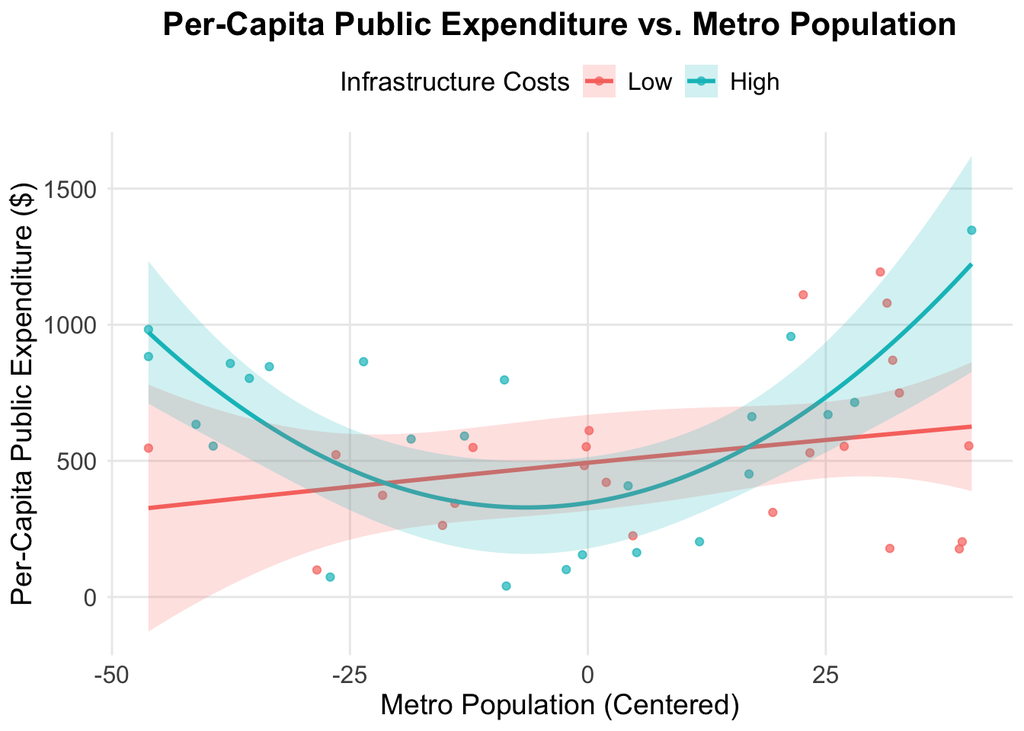

```r
new_data <- expand.grid(met_centered = seq(min(d$met_centered), max(d$met_centered), length.out = 100),
                        grp = c(-0.5, 0.5))

predictions <- predict(interaction_model, newdata = new_data, interval = "confidence")
new_data <- cbind(new_data, predictions)

ggplot() +
  geom_point(data = d, aes(x = met_centered, y = ex, color = factor(grp)), alpha = 0.7, linewidth = 0.5) +
  geom_line(data = new_data, aes(x = met_centered, y = fit, color = factor(grp)), linewidth = 1) +
  geom_ribbon(data = new_data, aes(x = met_centered, ymin = lwr, ymax = upr, fill = factor(grp)), alpha = 0.2, color = NA) +
  labs(title = "Per-Capita Public Expenditure vs. Metro Population",
       x = "Metro Population (Centered)",
       y = "Per-Capita Public Expenditure ($)",
       color = "Infrastructure Costs",
       fill = "Infrastructure Costs") +
  scale_color_discrete(labels = c("Low", "High")) +
  scale_fill_discrete(labels = c("Low", "High")) +
  theme_minimal() +
  theme(
    plot.title = element_text(size = 16, face = "bold", hjust = 0.5),
    axis.title = element_text(size = 14),
    axis.text = element_text(size = 12),
    legend.title = element_text(size = 13),
    legend.text = element_text(size = 12),
    legend.position = "top",
    panel.grid.minor = element_blank()
  )
```

## Part 2: Study 2: Interactive Effects of Sleep Deprivation and Caffeine Intake on Cognitive Performance - The Moderating Role of Baseline Anxiety

Cognitive performance is influenced by a complex interplay of physiological and psychological factors, particularly in contexts where sleep deprivation and stimulant use are prevalent. While caffeine is widely consumed to counteract cognitive deficits associated with insufficient sleep, its efficacy may depend on individual differences in baseline anxiety. The present study examines the interactive effects of sleep deprivation and caffeine intake on cognitive performance, with a focus on whether baseline anxiety moderates these effects. Thirty-five participants completed cognitive tasks under varying sleep and caffeine conditions, allowing for an investigation of both main effects and interaction effects on performance outcomes. Baseline anxiety was assessed prior to testing to evaluate its potential role in modulating cognitive responses to sleep loss and caffeine consumption. The findings contribute to a more nuanced understanding of how cognitive function is affected by physiological stressors and stimulants, with implications for optimizing performance in high-demand environments.

**Codebook:**

- `subid`: Subject ID codes. Values: 1-35
- `sleep`: Amount of sleep deprivation as reported by the participant. Values: Deprived or Rested
- `caffeine`: Indicator of caffeine consumption. Values: Yes or No
- `anxiety`: Ratings of how much anxiety participant experiences based on a standardized test. Values: 1-100
- `performance`: The aggregate score on a standardized test to evaluate cognitive performance levels. Values: 1-100

### 1. Read in your data (hw_19_data.csv), convert names to snake case if needed, and use a function to check whether your case conversion was successful. Are there any missing data entries? Are you concerned? Why or why not?

```r
d2 <- read_csv(here::here(path_data, "hw_19_data.csv"),
              show_col_types = FALSE) |>
  janitor::clean_names("snake") |>
  glimpse()
```

```
Rows: 35
Columns: 6
$ id           <dbl> 1, 2, 3, 4, 5, 6, 7, 8, 9, 10, 11, 12, 13, 14, 15, 16, 17…
$ anxiety      <dbl> 56.20757, 50.35641, 57.73154, 62.72489, 53.70975, 48.3714…
$ deprived_no  <dbl> NA, 49.67914, 39.33146, 39.28558, 37.00508, 51.15023, 42.…
$ rested_no    <dbl> 59.55647, 66.25871, 50.03478, 60.53870, 58.07609, 63.6304…
$ deprived_yes <dbl> 27.05628, 45.57967, 39.14081, 32.75639, 41.52902, 35.4006…
$ rested_yes   <dbl> 75.12826, 68.39112, 68.13657, NA, 72.73954, 68.28235, 73.…
```

```r
skim(d)
```

Data summary

| Name | d |
| --- | --- |
| Number of rows | 48 |
| Number of columns | 4 |
| _______________________ |  |
| Column type frequency: |  |
| numeric | 4 |
| ________________________ |  |
| Group variables | None |

**Variable type: numeric**

| skim_variable | n_missing | complete_rate | mean | sd | p0 | p25 | p50 | p75 | p100 | hist |
| --- | --- | --- | --- | --- | --- | --- | --- | --- | --- | --- |
| ex | 0 | 1 | 559.05 | 319.80 | 40.14 | 298.63 | 552.43 | 798.66 | 1346.96 | ▆▇▅▅▂ |
| met | 0 | 1 | 46.17 | 26.94 | 0.00 | 24.10 | 46.15 | 69.97 | 86.50 | ▅▆▇▃▇ |
| grp | 0 | 1 | 0.00 | 0.51 | -0.50 | -0.50 | 0.00 | 0.50 | 0.50 | ▇▁▁▁▇ |
| met_centered | 0 | 1 | 0.00 | 26.94 | -46.17 | -22.07 | -0.02 | 23.81 | 40.33 | ▅▆▇▃▇ |

```r
d2 <- d2 |> filter(!is.na(rested_yes) & !is.na(deprived_no))
```

I am slightly concerned with some missing data so I dropped them.

### 2. Prepare your data for analysis. What format is your data in? Ensure that your data is in long-format for the rest of the analysis. Make sure your variables are appropriately classed and centered for fitting regression models. This should include, for instance, making sure there aren’t any numeric variables that were accidentally read in as characters. Create faceted plots showing the effects of caffeine, sleep, and anxiety on performance for each subject ID. To make a TA smile, try doing this using the `map()` function!

```r
d2_long <- d2 |>
  pivot_longer(cols = starts_with("deprived") | starts_with("rested"),
               names_to = c("sleep", "caffeine"),
               names_pattern = "(deprived|rested)_(no|yes)",
               values_to = "performance") |>
  mutate(
    sleep = factor(sleep, levels = c("deprived", "rested"), labels = c("Deprived", "Rested")),
    caffeine = factor(caffeine, levels = c("no", "yes"), labels = c("No", "Yes")),
    anxiety = scale(anxiety, center = TRUE, scale = FALSE) # Center anxiety
  )

glimpse(d2_long)
```

[output not shown]

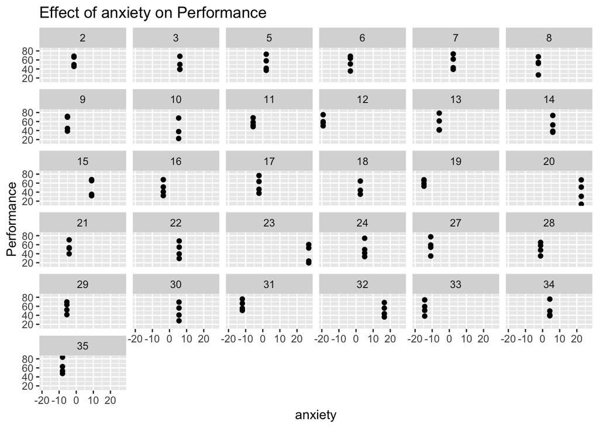

```r
plot_list <- map(c("anxiety"), ~ ggplot(d2_long, aes(x = .data[[.x]], y = performance)) +
                    geom_point() +
                    geom_smooth(method = "lm", se = FALSE) +
                    facet_wrap(~ id) +
                    labs(title = paste("Effect of", .x, "on Performance"),
                         x = .x,
                         y = "Performance"))

print(plot_list)
```

My data was in wide format, now it is in long format.

### 3. Testing appropriate model for the reseachers’ original hypothesis Run the model. Make sure to account for repeated measures and assume that the individual differences between participants in `caffeine`, `sleep` and `anxiety` do not influence/affect `performance` when specifying the mixed-effects linear model. Generate F-statistics for each predictor.

```r
model_mixed <- lmer(performance ~ anxiety + caffeine + sleep + (1 | id), data = d2_long)
```

```
boundary (singular) fit: see help('isSingular')
```

```r
summary(model_mixed)
```

```
Linear mixed model fit by REML ['lmerMod']
Formula: performance ~ anxiety + caffeine + sleep + (1 | id)
   Data: d2_long

REML criterion at convergence: 829.7

Scaled residuals:
    Min      1Q  Median      3Q     Max
-2.4559 -0.6809  0.0386  0.6760  1.8804

Random effects:
 Groups   Name        Variance Std.Dev.
 id       (Intercept)  0.00    0.000
 Residual             55.44    7.446
Number of obs: 122, groups:  id, 31

Fixed effects:
            Estimate Std. Error t value
(Intercept) 39.77320    1.16142  34.245
anxiety     -0.46988    0.06689  -7.024
caffeineYes  2.32741    1.34863   1.726
sleepRested 23.83015    1.34863  17.670

Correlation of Fixed Effects:
            (Intr) anxity cffnYs
anxiety      0.004
caffeineYes -0.581 -0.007
sleepRested -0.561  0.007 -0.017
optimizer (nloptwrap) convergence code: 0 (OK)
boundary (singular) fit: see help('isSingular')
```

```r
anova(model_mixed, type = 3, test = "F")
```

```
Analysis of Variance Table
         npar  Sum Sq Mean Sq  F value
anxiety     1  2816.9  2816.9  50.8087
caffeine    1   226.5   226.5   4.0856
sleep       1 17310.0 17310.0 312.2260
```

```r
model_compact <- lm(performance ~ anxiety + caffeine + sleep, data = d2_long)
summary(model_compact)
```

```
Call:
lm(formula = performance ~ anxiety + caffeine + sleep, data = d2_long)

Residuals:
     Min       1Q   Median       3Q      Max
-18.2865  -5.0696   0.2874   5.0331  14.0015

Coefficients:
            Estimate Std. Error t value Pr(>|t|)
(Intercept) 39.77320    1.16142  34.245  < 2e-16 ***
anxiety     -0.46988    0.06689  -7.024 1.48e-10 ***
caffeineYes  2.32741    1.34863   1.726    0.087 .
sleepRested 23.83015    1.34863  17.670  < 2e-16 ***
---
Signif. codes:  0 '***' 0.001 '**' 0.01 '*' 0.05 '.' 0.1 ' ' 1

Residual standard error: 7.446 on 118 degrees of freedom
  (2 observations deleted due to missingness)
Multiple R-squared:  0.7568,    Adjusted R-squared:  0.7506
F-statistic: 122.4 on 3 and 118 DF,  p-value: < 2.2e-16
```

```r
peta_value <- peta(model_compact, model_mixed)
print(peta_value)
```

```
[1] -2.780483e-16
```

```r
confint(model_mixed, level = 0.95)
```

```
Computing profile confidence intervals ...
```

```
                 2.5 %     97.5 %
.sig01       0.0000000  1.8974905
.sigma       6.4918673  8.3472860
(Intercept) 37.5167478 42.0296612
anxiety     -0.5998474 -0.3399209
caffeineYes -0.2927608  4.9475720
sleepRested 21.2099798 26.4503126
```

### 4. Write an appropriate, formal summary of the results, as if you were giving this report to a scientific colleague. In addition to a brief introduction to the study and its goals, your report should include appropriate b values and F-statistics (including degrees of freedom). You should report every predictor (aside from the intercept), regardless of significance. State whether the researchers’ hypothesis was confirmed.

Conclusion: The researchers’ hypothesis was partially confirmed, as anxiety and sleep conditions significantly influenced performance, with a significant negative relationship for anxiety and a significant positive relationship for sleep. The effect of caffeine was marginally significant, suggesting a potential but less robust influence on performance. The small peta value indicates that including random intercepts for participants had minimal effect on the model’s overall explanatory power.

### 5. Create a publication quality graph to accompany your write-up in Question-9 above. Generate one plot for the three-way interaction and another one for two-way interactions between the dichotomous variables. Hint: What type of interaction are we testing for? This should suggest what plots to generate for the two cases

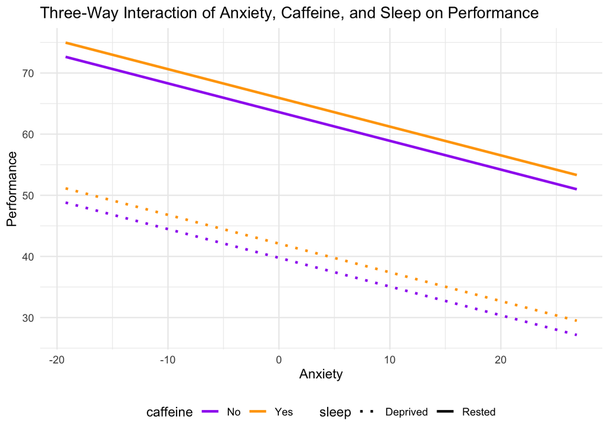

```r
#Threeway
interaction_data <- expand.grid(
  anxiety = seq(min(d2_long$anxiety), max(d2_long$anxiety), length.out = 100),
  caffeine = c("No", "Yes"),
  sleep = c("Deprived", "Rested")
)

interaction_data$caffeine <- factor(interaction_data$caffeine, levels = levels(d2_long$caffeine))
interaction_data$sleep <- factor(interaction_data$sleep, levels = levels(d2_long$sleep))

interaction_data$performance <- predict(model_mixed, newdata = interaction_data, re.form = NA)

ggplot(interaction_data, aes(x = anxiety, y = performance, color = caffeine, linetype = sleep)) +
  geom_line(size = 1) +
  labs(title = "Three-Way Interaction of Anxiety, Caffeine, and Sleep on Performance",
       x = "Anxiety", y = "Performance") +
  theme_minimal() +
  scale_color_manual(values = c("No" = "purple", "Yes" = "orange")) +
  scale_linetype_manual(values = c("Deprived" = "dotted", "Rested" = "solid")) +
  theme(legend.position = "bottom")
```

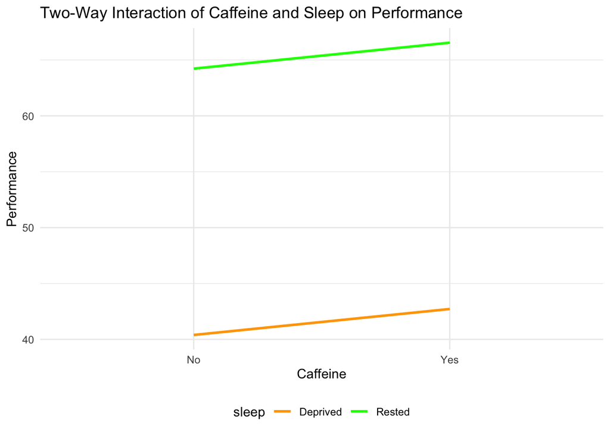

```r
#Twoway
interaction_data_2way <- expand.grid(
  anxiety = median(d2_long$anxiety),
  caffeine = c("No", "Yes"),
  sleep = c("Deprived", "Rested")
)

interaction_data_2way$caffeine <- factor(interaction_data_2way$caffeine, levels = levels(d2_long$caffeine))
interaction_data_2way$sleep <- factor(interaction_data_2way$sleep, levels = levels(d2_long$sleep))

interaction_data_2way$performance <- predict(model_mixed, newdata = interaction_data_2way, re.form = NA)

ggplot(interaction_data_2way, aes(x = caffeine, y = performance, color = sleep, group = sleep)) +
  geom_line(size = 1) +
  labs(title = "Two-Way Interaction of Caffeine and Sleep on Performance",
       x = "Caffeine", y = "Performance") +
  theme_minimal() +
  scale_color_manual(values = c("Deprived" = "orange", "Rested" = "green")) +
  theme(legend.position = "bottom")
```

## Wrap up.

###1. Please document questions where you used ChatGPT or other generative LLMs for assistance. Remember that this must include the corresponding exam question number, the input question you provided to the LLM, and the response you received. If you did not use any generative LLMs for this exam, please indicate that below. (1)

None

###2. How many hours did this assignment take you? (1)

7 hours.